# DSAN5900 HW1

Improving Our Selection Process For Diversity & Inclusion

Author

Chuyun Kuang & Linda Ding

Published

February 22, 2025

[figure not shown]

## 1 Introduction

Every year, thousands of students apply for competitive summer internships, hoping to gain hands-on experience, build industry connections, and set themselves apart in the job market. Yet, not all applications are judged equally. While some students secure coveted spots with ease, others—despite strong credentials—face rejection or indefinite waitlisting.

In recent years, concerns about **internship selection fairness** have gained attention.

> Are companies prioritizing the right candidates?

> Are **GPA and test scores** the best predictors of success in the workplace?

> Are students from **certain universities or regions** getting an unfair advantage?

To answer these questions, we analyzed data from our university to uncover trends in internship selection. Through this data-driven investigation, we aim to **unravel the hidden patterns behind internship offers, rejections, and waitlists**—ultimately helping students and recruiters make smarter, fairer decisions.

## 2 Performance Metrics

### 2.1 School Performance Metrics

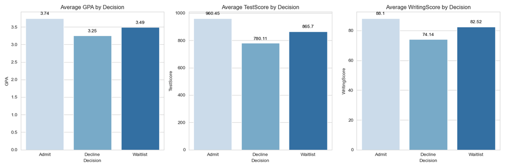

School Performance Metrics

The first set of charts shows how **GPA, test scores, and writing scores** differ across admissions decisions. Overall, applicants generally outperform candidates and rejections academically, with high GPAs and test scores clearly making it easier to gain admission, while lower academic scores are more likely to lead to rejection. Candidates’ academic performance, while better than those rejected, did not meet the criteria for direct admission, which may indicate that they were lacking in other areas or failed to stand out in a highly competitive situation. The trend in writing scores was similar to GPA and test scores, with applicants performing significantly better in writing, candidates second, and rejections having the lowest writing scores. This suggests that **academic performance** remains a key factor in determining admissions in the overall assessment, while writing ability may also influence application outcomes in specific circumstances, but to a lesser extent.

### 2.2 Extracurricular Performance Metrics

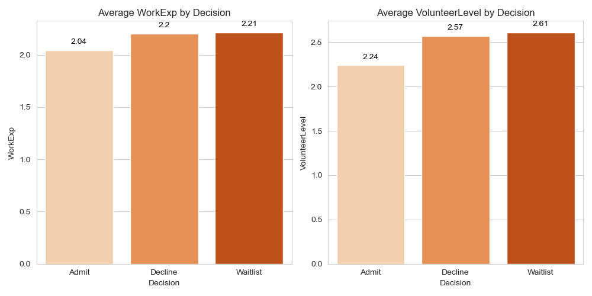

Extracurricular Performance Metrics

The second set of charts analyzed **practical experience**, including work experience and volunteer activities. The results showed that higher work and volunteer experience did not significantly increase the acceptance rate of applicants, but was more common among candidates and rejections. This suggests that while practical experience may be part of the assessment, it is not a substitute for academic achievement as the determining factor for admission. Although the practical experience of the applicants also has a certain accumulation, but in contrast, their advantages in academic performance are more obvious. This trend suggests that relying on practical experience alone may **not be enough** to compensate for academic shortcomings in the application process, and that admissions decisions are more likely to consider practical background on the basis of academic excellence.

To sum up, although practical experience may enhance the competitiveness of applicants to a certain extent, it cannot completely replace academic performance, and the final admission is still based on academic ability as the core evaluation criteria.

### 2.3 Comparison of two metrics

[figure not shown]

This dataset captures key **academic** and **extracurricular** metrics of students applying for a program, including **GPA**, **work experience**, **test scores**, **writing scores**, and **volunteer levels**. Additionally, it records the final admission decision, categorized into **Admitted** (red), **Declined** (blue), and **Waitlisted** (orange). These metrics help provide an overview of applicants’ profiles and allow for deeper analysis of the factors influencing admission outcomes.

The visualization is interactive, with **dynamic X and Y axes** that enable users to explore relationships between different variables. Each data point represents an applicant, with colors distinguishing their admission status. Reference lines display **average values**, offering a benchmark for comparison. This interactive design allows for flexible data exploration, enabling users to focus on specific aspects of the dataset based on their selections.

## 3 Geographical Factors

In this section, we focus on geographic factor to assess the fairness of the summer admission selection process and determine whether any biases exist.

> Where Do Applicants Come From?

To begin, we aim to gain a general geographical overview of the applicants to understand where they come from and how location influences admission decisions.

The first visualization provides a geographical breakdown of summer admission decisions across various states. The pie charts represent the proportion of applicants who were **admitted (blue)**, **declined (red)**, or **waitlisted (orange)** in different locations.

[figure not shown]

The map reveals that the majority of applicants come from **California, Utah, Colorado, and Florida**. This raises an important question: Do these regions offer stronger networks or better resources that encourage more students to apply?

Additionally, we observe notable differences in admission outcomes across states. **California and Colorado** have a higher proportion of admitted students, suggesting that applicants from these regions may have stronger profiles or that these states are more favored in the selection process. In contrast, Utah show a higher proportion of declined applicants, pointing to potential regional disparities in acceptance rates.

Another interesting pattern is the **significant number of waitlisted students in some states** (such as in Virginia), which could indicate a strategic approach to managing yield rates and optimizing enrollment.

These findings lead us to critical questions: Are students from certain states at a disadvantage due to quotas or implicit biases? Do in-state applicants receive preferential treatment over out-of-state students? Understanding these regional differences is essential to ensuring a fair and equitable admissions process.

### 3.1 How Does GPA Influence Admission?

[figure not shown]

The second visualization examines the relationship between GPA and summer admission decisions across different states. **Darker shades** on the map indicate **higher average GPAs** for each admission category.

From this analysis, we see a clear pattern: students with **higher GPAs** are more likely to be **admitted**, especially in states like California, Colorado, and Florida. Conversely, states with a higher proportion of rejected applicants tend to have lower GPAs, as seen in lighter-colored states like Virginia.

Interestingly, waitlisted students often have intermediate GPAs, suggesting that while academic performance is important, it is **not the sole factor determining admission**. This insight raises important strategic considerations: Are we rejecting high-GPA students from certain states due to capacity limits or other institutional priorities? Should we reconsider admission criteria to ensure we are not missing out on strong candidates from specific regions?

## 4 Gender Factors

In this section, we focus on gender factor to assess the fairness of the summer admission selection process and determine whether any biases exist.

> Gender Disparities in Admission Decisions: Do Male and Female Applicants Face Different Outcomes?

[figure not shown]

This visualization presents a comparative analysis of admission outcomes for male and female applicants applying for summer internships. The pie charts illustrate the distribution of decisions for each gender, categorized into **admitted (blue)**, **declined (red)**, and **waitlisted (orange)**.

From the overview plot, we found that we obtained **more male applicants** compared to female.

Moreover, there was **similar acceptance rates, decline rates, and waitlist rates** for male and female applicants. For example, 13 female applicants and 16 male applicants were admitted. While males have slightly higher absolute numbers in acceptance, this may be due to a larger overall male applicant pool rather than a distinct preference for one gender over another.

Therefore, the admission decisions between male and female applicants appear to be generally fair. Next, we will delve deeper into the statistical summary of male and female applicants, focusing on their **academic performance** and **extracurricular activities**.

### 4.1 The Story Behind the Numbers: How Do Male and Female Applicants Compare?

After examining overall admission decisions, we now shift our focus to academic performance and extracurricular activities to uncover potential patterns influencing male and female applicants’ outcomes. This statistical summary provides key insights into how **GPA, test scores, volunteer work, work experience, and writing skills** contribute to internship selection.

[figure not shown]

The table reveals an interesting trend: **female applicants who were admitted had lower academic performance** than their male counterparts but **compensated with stronger work experience and volunteer engagement**.

- **Lower Academic Performance for Admitted Females**
  - Admitted females had an average GPA of 3.7 and a test score of 952.8, compared to admitted males with a GPA of 3.8 and a test score of 966.6.
  - This suggests that academics were slightly less emphasized in the selection of female applicants.
- **More Work & Volunteer Experience Among Admitted Females**
  - Females had higher volunteer levels (2.4 vs. 2.1) and slightly more work experience (2.2 vs. 1.9).
  - This suggests that practical experience and extracurricular involvement played a bigger role in female selections compared to males.

However, this trend only applies to admitted applicants. From the table, we found that

- **Work & Volunteer Experience Don’t Guarantee Acceptance**
  - Waitlisted applicants had the highest volunteer & work experience, suggesting that well-rounded candidates without standout academic records are often put on hold.
  - Rejected male applicants had the highest volunteer level (3.0), but it didn’t compensate for lower GPAs and writing scores.

## 5 Conclusion

The analysis of summer internship admission decisions has revealed key patterns in **geographic**, **gender**, and **academic factors** influencing applicant outcomes.

**Key Takeaways**

1. **Academic Performance Remains the Strongest Predictor of Admission**
- Higher GPA and test scores correlate with higher acceptance rates.
- However, admitted female applicants had slightly lower academic scores but stronger work and volunteer experience, suggesting a more holistic selection approach for female candidates.
2. **Work & Volunteer Experience Matter, But Not as Much as Academics**
- Waitlisted and rejected candidates often had the highest work and volunteer experience, indicating that while extracurriculars are valued, they are not the primary determinant of admission.
3. **Gender Differences Are Minimal in Overall Selection, But Selection Criteria May Vary**
- The admission rates between male and female applicants are relatively similar in terms of proportions.
- However, males who were admitted had stronger academic records, whereas females compensated with higher extracurricular involvement.
4. **Geographic Location Plays a Role in Admission Outcomes**
- Certain states, like California and Colorado, had higher acceptance rates, suggesting stronger applicant profiles or institutional preferences.
- Other states, like Utah and Virginia, had higher rejection rates, raising questions about regional disparities in the selection process.

### 5.1 Moving Forward

Moving forward, one area for further exploration is the role of industry preferences in shaping admission decisions. Do certain industries or roles favor applicants with more experience over higher academic performance? Additionally, it would be valuable to examine **whether female applicants are applying to different fields than males**, which may contribute to variations in selection criteria.

Finally, it is crucial to enhance fairness in the selection process to prevent the exclusion of qualified candidates. Recruiters and universities should reevaluate admission criteria to ensure selection biases do not disadvantage applicants from **certain states, academic backgrounds, or gender groups**. More efforts are needed to bridge the gap for applicants from underrepresented regions, ensuring equal access to internship opportunities.

## 6 Code

Check out the code used in our analysis [here](https://github.com/cyKuang/dsan5900HW1)!